# ASSIGNMENT2

deepak

2023-10-04

```r
knitr::opts_chunk$set(echo = TRUE)
```

```r
#install.packages("readr")
library(readr)
#install.packages("lattice")
library(lattice)
#install.packages("caret")
library(caret)
```

```r
#install.packages("ISLR")
library(ISLR)
#install.packages("ggplot2")
library(ggplot2)
#install.packages("FNN")
library(FNN)
#install.packages("plyr")
library("plyr")
#install.packages("gmodels")
library(gmodels)
#install.packages("ggplot2")
library(ggplot2)
```

#Importing Data, Data visulization & Data Summary #a.Age = 40, Experience = 10, Income = 84, Family = 2, CCAvg = 2, Education_1 = 0, Education_2 =1, Education_3 = 0, Mortgage = 0, Securities Account = 0, CD Account = 0, Online = 1, and Credit Card = 1. Perform a k-NN classification with all predictors except ID and ZIP code using k = 1. Remember to transform categorical predictors with more than two categories into dummy variables first. Specify the success class as 1 (loan acceptance), and use the default cutoff value of 0.5. How would this customer be classified?

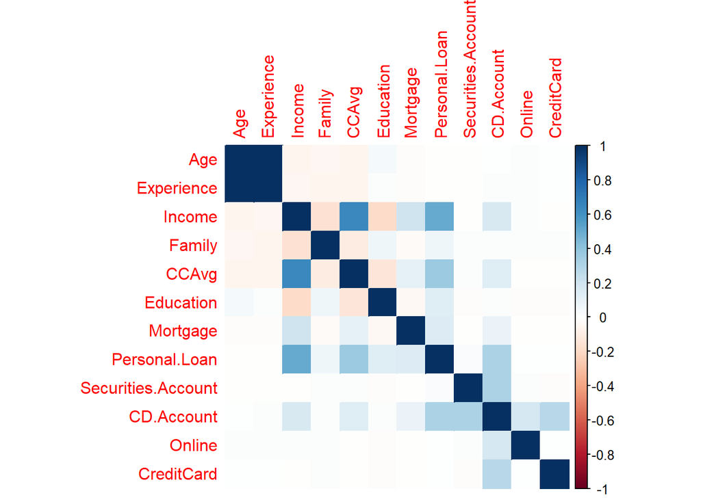

```r
options(stringsAsFactors = FALSE)
UniversalBank <- read.csv("C:/Users/durga/OneDrive/Desktop/UniversalBank.csv")
Universalbank_num <-UniversalBank [, c(2:4,6:14)]
#install.packages("corrplot")
library(corrplot)
corrplot(cor(Universalbank_num), method="color")
```

```r
summary(Universalbank_num)
```

```
##       Age          Experience       Income           Family
##  Min.   :23.00   Min.   :-3.0   Min.   :  8.00   Min.   :1.000
##  1st Qu.:35.00   1st Qu.:10.0   1st Qu.: 39.00   1st Qu.:1.000
##  Median :45.00   Median :20.0   Median : 64.00   Median :2.000
##  Mean   :45.34   Mean   :20.1   Mean   : 73.77   Mean   :2.396
##  3rd Qu.:55.00   3rd Qu.:30.0   3rd Qu.: 98.00   3rd Qu.:3.000
##  Max.   :67.00   Max.   :43.0   Max.   :224.00   Max.   :4.000
##      CCAvg          Education        Mortgage     Personal.Loan
##  Min.   : 0.000   Min.   :1.000   Min.   :  0.0   Min.   :0.000
##  1st Qu.: 0.700   1st Qu.:1.000   1st Qu.:  0.0   1st Qu.:0.000
##  Median : 1.500   Median :2.000   Median :  0.0   Median :0.000
##  Mean   : 1.938   Mean   :1.881   Mean   : 56.5   Mean   :0.096
##  3rd Qu.: 2.500   3rd Qu.:3.000   3rd Qu.:101.0   3rd Qu.:0.000
##  Max.   :10.000   Max.   :3.000   Max.   :635.0   Max.   :1.000
##  Securities.Account   CD.Account         Online         CreditCard
##  Min.   :0.0000     Min.   :0.0000   Min.   :0.0000   Min.   :0.000
##  1st Qu.:0.0000     1st Qu.:0.0000   1st Qu.:0.0000   1st Qu.:0.000
##  Median :0.0000     Median :0.0000   Median :1.0000   Median :0.000
##  Mean   :0.1044     Mean   :0.0604   Mean   :0.5968   Mean   :0.294
##  3rd Qu.:0.0000     3rd Qu.:0.0000   3rd Qu.:1.0000   3rd Qu.:1.000
##  Max.   :1.0000     Max.   :1.0000   Max.   :1.0000   Max.   :1.000
```

```r
head(UniversalBank,10)
```

```
##    ID Age Experience Income ZIP.Code Family CCAvg Education Mortgage
## 1   1  25          1     49    91107      4   1.6         1        0
## 2   2  45         19     34    90089      3   1.5         1        0
## 3   3  39         15     11    94720      1   1.0         1        0
## 4   4  35          9    100    94112      1   2.7         2        0
## 5   5  35          8     45    91330      4   1.0         2        0
## 6   6  37         13     29    92121      4   0.4         2      155
## 7   7  53         27     72    91711      2   1.5         2        0
## 8   8  50         24     22    93943      1   0.3         3        0
## 9   9  35         10     81    90089      3   0.6         2      104
## 10 10  34          9    180    93023      1   8.9         3        0
##    Personal.Loan Securities.Account CD.Account Online CreditCard
## 1              0                  1          0      0          0
## 2              0                  1          0      0          0
## 3              0                  0          0      0          0
## 4              0                  0          0      0          0
## 5              0                  0          0      0          1
## 6              0                  0          0      1          0
## 7              0                  0          0      1          0
## 8              0                  0          0      0          1
## 9              0                  0          0      1          0
## 10             1                  0          0      0          0
```

```r
# Perform a k-NN classification with all predictors except ID and ZIP code using k = 1.

 UniversalBank<- subset(UniversalBank, select = -c(ZIP.Code,ID))
# convert the education variable as factor
UniversalBank$Education <- as.factor(UniversalBank$Education)
str(UniversalBank)
```

```
## 'data.frame':    5000 obs. of  12 variables:
##  $ Age               : int  25 45 39 35 35 37 53 50 35 34 ...
##  $ Experience        : int  1 19 15 9 8 13 27 24 10 9 ...
##  $ Income            : int  49 34 11 100 45 29 72 22 81 180 ...
##  $ Family            : int  4 3 1 1 4 4 2 1 3 1 ...
##  $ CCAvg             : num  1.6 1.5 1 2.7 1 0.4 1.5 0.3 0.6 8.9 ...
##  $ Education         : Factor w/ 3 levels "1","2","3": 1 1 1 2 2 2 2 3 2 3 ...
##  $ Mortgage          : int  0 0 0 0 0 155 0 0 104 0 ...
##  $ Personal.Loan     : int  0 0 0 0 0 0 0 0 0 1 ...
##  $ Securities.Account: int  1 1 0 0 0 0 0 0 0 0 ...
##  $ CD.Account        : int  0 0 0 0 0 0 0 0 0 0 ...
##  $ Online            : int  0 0 0 0 0 1 1 0 1 0 ...
##  $ CreditCard        : int  0 0 0 0 1 0 0 1 0 0 ...
```

```r
# Create dummies for education variable
library(dummies)
education = dummy(UniversalBank$Education)
```

#Convert Education to dummy variables

```r
library(fastDummies)
Universalbank_dummy <- dummy_cols(Universalbank_num, select_columns = "Education")
```

#Splitting data Training : 60% , Validation : 40%

```r
set.seed(1)
#splitting 60% of data into training & 40% of data into validation
Train_index <- createDataPartition(Universalbank_dummy$'Personal.Loan', p=0.6, list=FALSE)
Training_data <-Universalbank_dummy[Train_index,]
Validation_data <-Universalbank_dummy [-Train_index,]
summary(Training_data)
```

```
##       Age          Experience        Income           Family
##  Min.   :23.00   Min.   :-3.00   Min.   :  8.00   Min.   :1.000
##  1st Qu.:36.00   1st Qu.:10.00   1st Qu.: 39.00   1st Qu.:1.000
##  Median :45.00   Median :20.00   Median : 63.00   Median :2.000
##  Mean   :45.43   Mean   :20.19   Mean   : 73.08   Mean   :2.388
##  3rd Qu.:55.00   3rd Qu.:30.00   3rd Qu.: 98.00   3rd Qu.:3.000
##  Max.   :67.00   Max.   :43.00   Max.   :224.00   Max.   :4.000
##      CCAvg          Education       Mortgage      Personal.Loan
##  Min.   : 0.000   Min.   :1.00   Min.   :  0.00   Min.   :0.00000
##  1st Qu.: 0.700   1st Qu.:1.00   1st Qu.:  0.00   1st Qu.:0.00000
##  Median : 1.500   Median :2.00   Median :  0.00   Median :0.00000
##  Mean   : 1.915   Mean   :1.88   Mean   : 57.34   Mean   :0.09167
##  3rd Qu.: 2.500   3rd Qu.:3.00   3rd Qu.:102.00   3rd Qu.:0.00000
##  Max.   :10.000   Max.   :3.00   Max.   :635.00   Max.   :1.00000
##  Securities.Account   CD.Account          Online         CreditCard
##  Min.   :0.0000     Min.   :0.00000   Min.   :0.0000   Min.   :0.0000
##  1st Qu.:0.0000     1st Qu.:0.00000   1st Qu.:0.0000   1st Qu.:0.0000
##  Median :0.0000     Median :0.00000   Median :1.0000   Median :0.0000
##  Mean   :0.1003     Mean   :0.05367   Mean   :0.5847   Mean   :0.2927
##  3rd Qu.:0.0000     3rd Qu.:0.00000   3rd Qu.:1.0000   3rd Qu.:1.0000
##  Max.   :1.0000     Max.   :1.00000   Max.   :1.0000   Max.   :1.0000
##   Education_1      Education_2     Education_3
##  Min.   :0.0000   Min.   :0.000   Min.   :0.0000
##  1st Qu.:0.0000   1st Qu.:0.000   1st Qu.:0.0000
##  Median :0.0000   Median :0.000   Median :0.0000
##  Mean   :0.4173   Mean   :0.285   Mean   :0.2977
##  3rd Qu.:1.0000   3rd Qu.:1.000   3rd Qu.:1.0000
##  Max.   :1.0000   Max.   :1.000   Max.   :1.0000
```